# telecom customer churn

## Data Eexploration ¶

```python
DATA_PATH = "D:/projects/customer churn predection/customer_churn.csv"
```

```python
import pandas as pd
import numpy as np

import seaborn as sns
import matplotlib.pyplot as plt
pd.options.display.max_rows = 10000
```

```python
# Read data and print shape
raw_df = pd.read_csv(DATA_PATH)
df = raw_df.copy
raw_df.shape
```

```
(7043, 21)
```

```python
# Display random answer
# Observations: Multiple answers need to be splitted
# Reference to the schema needed to understand
raw_df.sample(1).iloc[0]
```

```
customerID              2709-UQGNP
gender                        Male
SeniorCitizen                    0
Partner                         No
Dependents                      No
tenure                          10
PhoneService                   Yes
MultipleLines                   No
InternetService                DSL
OnlineSecurity                 Yes
OnlineBackup                    No
DeviceProtection                No
TechSupport                     No
StreamingTV                     No
StreamingMovies                 No
Contract            Month-to-month
PaperlessBilling               Yes
PaymentMethod         Mailed check
MonthlyCharges               51.65
TotalCharges                 524.5
Churn                           No
Name: 5892, dtype: object
```

```python
# Print the general information of the data frame
raw_df.info()
```

```
<class 'pandas.core.frame.DataFrame'>
RangeIndex: 7043 entries, 0 to 7042
Data columns (total 21 columns):
 #   Column            Non-Null Count  Dtype
---  ------            --------------  -----
 0   customerID        7043 non-null   object
 1   gender            7043 non-null   object
 2   SeniorCitizen     7043 non-null   int64
 3   Partner           7043 non-null   object
 4   Dependents        7043 non-null   object
 5   tenure            7043 non-null   int64
 6   PhoneService      7043 non-null   object
 7   MultipleLines     7043 non-null   object
 8   InternetService   7043 non-null   object
 9   OnlineSecurity    7043 non-null   object
 10  OnlineBackup      7043 non-null   object
 11  DeviceProtection  7043 non-null   object
 12  TechSupport       7043 non-null   object
 13  StreamingTV       7043 non-null   object
 14  StreamingMovies   7043 non-null   object
 15  Contract          7043 non-null   object
 16  PaperlessBilling  7043 non-null   object
 17  PaymentMethod     7043 non-null   object
 18  MonthlyCharges    7043 non-null   float64
 19  TotalCharges      7043 non-null   object
 20  Churn             7043 non-null   object
dtypes: float64(1), int64(2), object(18)
memory usage: 1.1+ MB
```

```python
# Get stats for the numerical column
raw_df.describe()
```

|  | SeniorCitizen | tenure | MonthlyCharges |
| --- | --- | --- | --- |
| count | 7043.000000 | 7043.000000 | 7043.000000 |
| mean | 0.162147 | 32.371149 | 64.761692 |
| std | 0.368612 | 24.559481 | 30.090047 |
| min | 0.000000 | 0.000000 | 18.250000 |
| 25% | 0.000000 | 9.000000 | 35.500000 |
| 50% | 0.000000 | 29.000000 | 70.350000 |
| 75% | 0.000000 | 55.000000 | 89.850000 |
| max | 1.000000 | 72.000000 | 118.750000 |

```python
# Investigate the questionable objects column (TotalCharges)
raw_df.TotalCharges.value_counts()
```

```
           11
20.2       11
19.75       9
20.05       8
19.9        8
19.65       8
45.3        7
19.55       7
20.15       6
20.25       6
19.45       6
20.3        5
20.45       5
19.85       4
69.9        4
20.4        4
70.6        4
19.2        4
69.65       4
44          4
44.4        4
20.5        4
49.9        4
74.7        4
19.3        4
19.95       4
19.5        4
75.3        4
50.15       4
20.35       4
69.6        4
19.4        4
69.95       4
19.25       3
70.45       3
1284.2      3
69.25       3
74.3        3
20.9        3
220.45      3
```

[output cut: 6477 more lines]

```
2065.15     1
3838.2      1
168.9       1
7843.55     1
3306.85     1
424.75      1
6565.85     1
2117.2      1
203.95      1
6849.4      1
692.35      1
130.15      1
3211.9      1
6844.5      1
Name: TotalCharges, dtype: int64
```

# Processing

## Preprocess Data

```python
def fix_total_charges(row):
    if row['TotalCharges'] == ' ':
        return row['MonthlyCharges']
    else:
        return row['TotalCharges']

raw_df['TotalCharges'] = raw_df.apply(fix_total_charges, axis=1)
```

```python
# Handling TotalCharges "spaces"
raw_df["TotalCharges"] = pd.to_numeric(raw_df.TotalCharges,errors='coerce')
```

```python
# validate that spaces converted to nulls
raw_df.isnull().sum()
```

```
customerID          0
gender              0
SeniorCitizen       0
Partner             0
Dependents          0
tenure              0
PhoneService        0
MultipleLines       0
InternetService     0
OnlineSecurity      0
OnlineBackup        0
DeviceProtection    0
TechSupport         0
StreamingTV         0
StreamingMovies     0
Contract            0
PaperlessBilling    0
PaymentMethod       0
MonthlyCharges      0
TotalCharges        0
Churn               0
dtype: int64
```

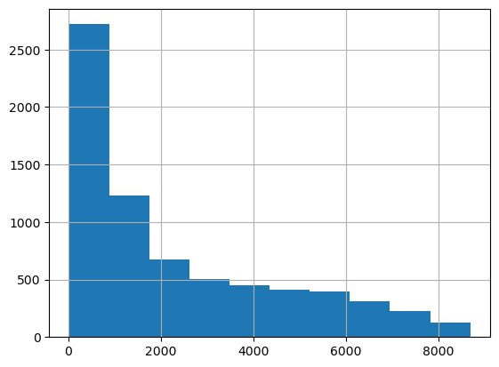

```python
# check distribution before handling null
raw_df.TotalCharges.hist()
```

```python
raw_df["TotalCharges"].fillna(raw_df["TotalCharges"].median, inplace=True)
```

```python
# nulls validation
raw_df.isnull().sum()
```

```
customerID          0
gender              0
SeniorCitizen       0
Partner             0
Dependents          0
tenure              0
PhoneService        0
MultipleLines       0
InternetService     0
OnlineSecurity      0
OnlineBackup        0
DeviceProtection    0
TechSupport         0
StreamingTV         0
StreamingMovies     0
Contract            0
PaperlessBilling    0
PaymentMethod       0
MonthlyCharges      0
TotalCharges        0
Churn               0
dtype: int64
```

### Senior Citizen

```python
raw_df['SeniorCitizen'] = raw_df['SeniorCitizen'].astype('object')
```

```python
# standardize columns names
raw_df.columns = raw_df.columns.str.lower()
```

```python
# drop unusable columns
raw_df.drop('customerid', axis=1, inplace= True)
```

# Analytics

```python
# Target coulmn analysis
#Convert churn to Numerical Value
raw_df.churn = (raw_df.churn == 'Yes').astype(int)
```

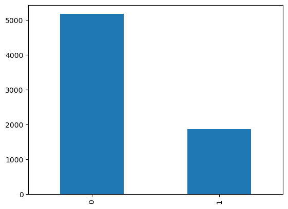

```python
raw_df.churn.value_counts().plot(kind='bar') #Imbalanced
```

```python
# churn ratio 26.5%
raw_df.churn.value_counts(normalize=True)
```

```
0    0.73463
1    0.26537
Name: churn, dtype: float64
```

```python
# split data frame features to categorical & numerical
cat_col = raw_df.select_dtypes(include='O').columns.tolist()
num_col = raw_df.select_dtypes(include='number' ).columns.tolist()
```

```python
num_col.remove('churn')
```

# Feature Importance

## Risk Ratio Method

#### risk = group rate / global rate

#### a group with a risk close to 1 is not risky at all

#### a group with a risk lower than 1:, the clients in this group are less likely to churn than clients in general

#### a group with a risk higher than 1: there’s more churn in the group than in the population '

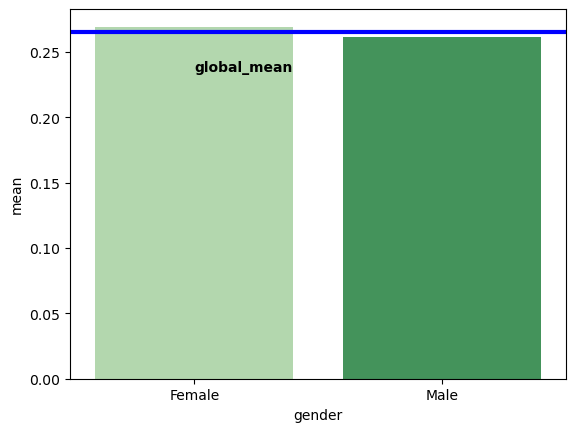

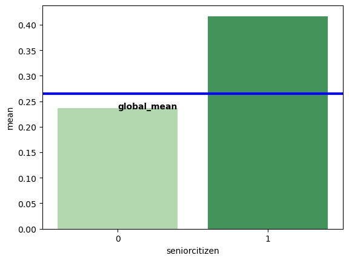

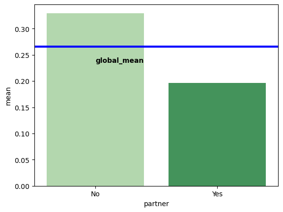

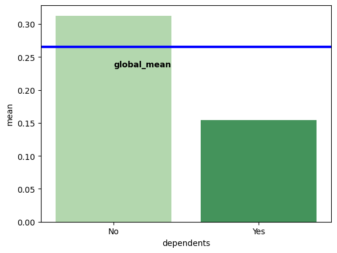

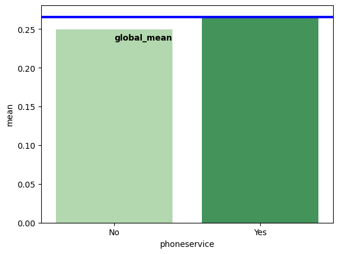

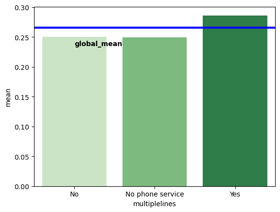

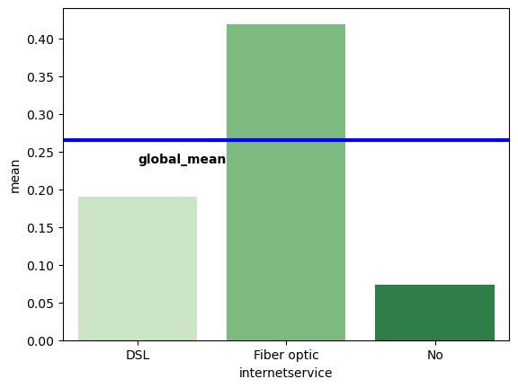

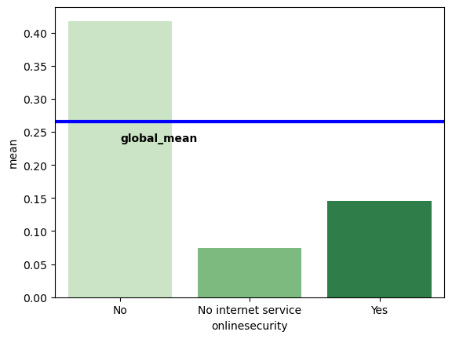

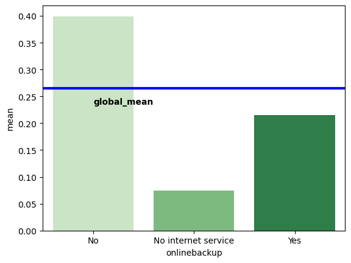

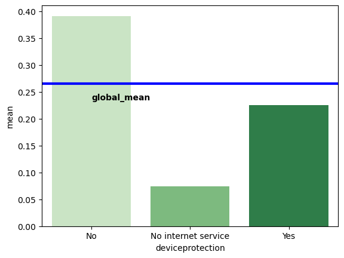

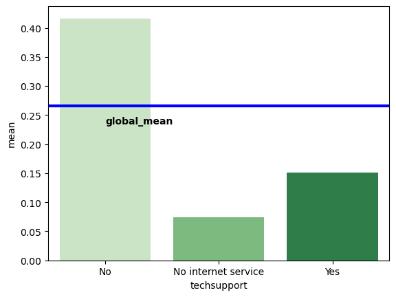

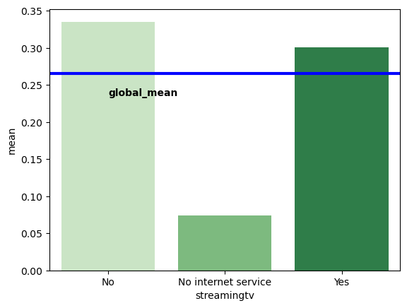

[4 more figures not shown]

```python
for feature in cat_col:
    df_group = raw_df.groupby(by=feature).churn.agg(['mean']).reset_index()
    global_mean = raw_df['churn'].mean()
    graph=sns.barplot(x= feature, y = 'mean', data=df_group, palette='Greens')
    graph.axhline(global_mean, linewidth=3, color='b')
    plt.text(0, global_mean - 0.03, "global_mean", color='black', weight='semibold')
    plt.show()
```

### Some Insights

For gender, there is not much difference between females and males.

Senior citizens tend to churn more than nonseniors.

People with a partner churn less than people with no partner.

People who use phone service are not at risk of churning. People who don’t use phone service are even less likely to churn.

Clients with no tech support tend to churn more than those who do.

People with monthly contracts cancel the contract a lot more often than others, and people with two-year contacts churn very rarely.

Let's validate with

### Mutual Information Method

More efficient to compare features importance

Mutual information is a way to quantify the degree of dependency between two categorical variables, but it doesn’t work when one of the features is numerical

MI(feature;target) = Entropy(feature) - Entropy(feature|target)

```python
from sklearn.metrics import mutual_info_score

def calculate_mi(series):
    return mutual_info_score(series, raw_df.churn)

df_mi = raw_df[cat_col].apply(calculate_mi)
df_mi = df_mi.sort_values(ascending=False).to_frame(name='MI')
display(df_mi.head(12))
display(df_mi.tail())
```

|  | MI |
| --- | --- |
| contract | 0.098453 |
| onlinesecurity | 0.064677 |
| techsupport | 0.063021 |
| internetservice | 0.055574 |
| onlinebackup | 0.046792 |
| paymentmethod | 0.044519 |
| deviceprotection | 0.043917 |
| streamingmovies | 0.032001 |
| streamingtv | 0.031908 |
| paperlessbilling | 0.019194 |
| dependents | 0.014467 |
| partner | 0.011454 |

|  | MI |
| --- | --- |
| partner | 0.011454 |
| seniorcitizen | 0.010577 |
| multiplelines | 0.000801 |
| phoneservice | 0.000072 |
| gender | 0.000037 |

## Importace of Numerical Features

### Correlation Coefficient

```python
raw_df[num_col].corrwith(raw_df.churn)
```

```
tenure           -0.352229
monthlycharges    0.193356
totalcharges     -0.198347
dtype: float64
```

### Tenure

The correlation between tenure and churn is –0.35: it has a negative sign, so the longer customers stay, the less often they tend to churn

```python
t1 =raw_df[raw_df['tenure'] <= 2].churn.mean()
t1
```

```
0.5835266821345708
```

```python
t2 = raw_df[(raw_df.tenure >= 3) & (raw_df.tenure <= 12)].churn.mean()
t2
```

```
0.4033232628398791
```

```python
t3 = raw_df[raw_df['tenure'] >= 12].churn.mean()
t3
```

```
0.17490952955367914
```

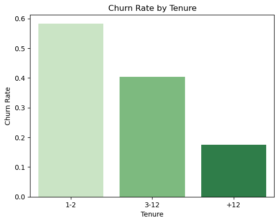

```python
sns.barplot(x =['1-2', '3-12', '+12'], y =[t1,t2,t3], palette='Greens');
plt.title('Churn Rate by Tenure');
plt.xlabel('Tenure');
plt.ylabel('Churn Rate');
```

### Monthly Charges

monthlycharges has a positive coefficient of 0.19, which means that customers who pay more tend to leave more often.

```python
mc1 =raw_df[raw_df['monthlycharges'] <= 20].churn.mean()
mc1
```

```
0.08841463414634146
```

```python
mc2 = raw_df[(raw_df.monthlycharges >= 21) & (raw_df.monthlycharges <= 50)].churn.mean()
mc2
```

```
0.22807017543859648
```

```python
mc3 = raw_df[raw_df['monthlycharges'] > 50].churn.mean()
mc3
```

```
0.3178752107925801
```

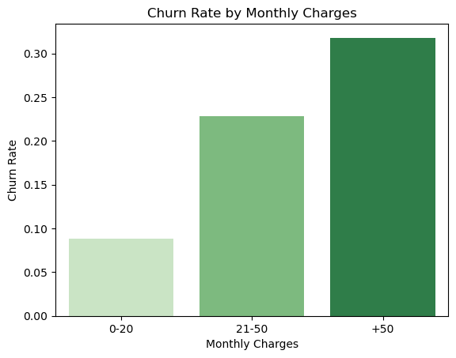

```python
sns.barplot(x =['0-20', '21-50', '+50'], y =[mc1,mc2,mc3], palette='Greens');
plt.title('Churn Rate by Monthly Charges');
plt.xlabel('Monthly Charges');
plt.ylabel('Churn Rate');
```

### Total Charges

totalcharges has a negative correlation, which makes sense: the longer people stay with the company, the more they have paid in total, so it’s less likely that they will leave.

```python
tc1 = raw_df[raw_df['totalcharges'] <= 1000].churn.mean()
tc1
```

```
0.36845730027548207
```

```python
tc2 = raw_df[(raw_df.totalcharges > 1000) & (raw_df.totalcharges <= 5000)].churn.mean()
tc2
```

```
0.2137150466045273
```

```python
tc3 = raw_df[raw_df['totalcharges'] > 5000].churn.mean()
tc3
```

```
0.13832599118942732
```

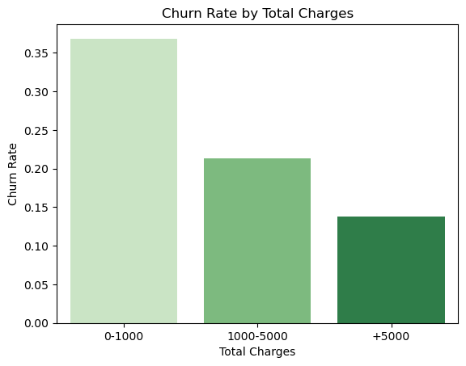

```python
sns.barplot(x =['0-1000', '1000-5000', '+5000'], y =[tc1,tc2,tc3], palette='Greens');
plt.title('Churn Rate by Total Charges');
plt.xlabel('Total Charges');
plt.ylabel('Churn Rate');
```

## Feature Engineering

### Data Splitting

```python
from sklearn.model_selection import train_test_split

df_full_train, df_test = train_test_split(raw_df, test_size=0.2, random_state=1)
df_train, df_valid = train_test_split(df_full_train, test_size=0.2, random_state=1)
print("Training Data Size: ", df_train.shape)
print("Validation Data Size: ", df_valid.shape)
print("Testing Data Size: ", df_test.shape)
```

```
Training Data Size:  (4507, 20)
Validation Data Size:  (1127, 20)
Testing Data Size:  (1409, 20)
```

#### Handling Categorical Variables one-hot encoding

```python
# Applying one hot encoding


from sklearn.preprocessing import OneHotEncoder
from sklearn.compose import make_column_transformer

ohe = OneHotEncoder(drop='first')

transformer = make_column_transformer((ohe, cat_col), remainder='passthrough',
                                      verbose_feature_names_out=False)

train_enc = transformer.fit_transform(df_train)
df_train_enc = pd.DataFrame(train_enc, columns=transformer.get_feature_names_out())
df_train_enc
```

|  | gender_Male | seniorcitizen_1 | partner_Yes | dependents_Yes | phoneservice_Yes | multiplelines_No phone service | multiplelines_Yes | internetservice_Fiber optic | internetservice_No | onlinesecurity_No internet service | ... | contract_One year | contract_Two year | paperlessbilling_Yes | paymentmethod_Credit card (automatic) | paymentmethod_Electronic check | paymentmethod_Mailed check | tenure | monthlycharges | totalcharges | churn |
| --- | --- | --- | --- | --- | --- | --- | --- | --- | --- | --- | --- | --- | --- | --- | --- | --- | --- | --- | --- | --- | --- |
| 0 | 1.0 | 0.0 | 0.0 | 0.0 | 1.0 | 0.0 | 0.0 | 0.0 | 1.0 | 1.0 | ... | 1.0 | 0.0 | 0.0 | 0.0 | 0.0 | 1.0 | 30.0 | 19.70 | 625.05 | 0.0 |
| 1 | 0.0 | 0.0 | 1.0 | 1.0 | 1.0 | 0.0 | 1.0 | 1.0 | 0.0 | 0.0 | ... | 0.0 | 0.0 | 1.0 | 0.0 | 1.0 | 0.0 | 23.0 | 83.75 | 1849.95 | 0.0 |
| 2 | 0.0 | 1.0 | 1.0 | 1.0 | 1.0 | 0.0 | 1.0 | 1.0 | 0.0 | 0.0 | ... | 0.0 | 0.0 | 1.0 | 0.0 | 1.0 | 0.0 | 14.0 | 95.80 | 1346.30 | 0.0 |
| 3 | 0.0 | 0.0 | 0.0 | 0.0 | 1.0 | 0.0 | 0.0 | 0.0 | 1.0 | 1.0 | ... | 0.0 | 1.0 | 0.0 | 0.0 | 0.0 | 0.0 | 56.0 | 19.70 | 1051.90 | 0.0 |
| 4 | 0.0 | 0.0 | 0.0 | 0.0 | 1.0 | 0.0 | 1.0 | 1.0 | 0.0 | 0.0 | ... | 0.0 | 1.0 | 0.0 | 1.0 | 0.0 | 0.0 | 63.0 | 98.00 | 6218.45 | 0.0 |
| 5 | 0.0 | 1.0 | 1.0 | 0.0 | 1.0 | 0.0 | 1.0 | 1.0 | 0.0 | 0.0 | ... | 0.0 | 0.0 | 1.0 | 0.0 | 0.0 | 0.0 | 33.0 | 80.60 | 2656.50 | 1.0 |
| 6 | 1.0 | 0.0 | 0.0 | 1.0 | 1.0 | 0.0 | 0.0 | 0.0 | 1.0 | 1.0 | ... | 0.0 | 0.0 | 0.0 | 0.0 | 0.0 | 1.0 | 2.0 | 19.25 | 48.35 | 0.0 |
| 7 | 1.0 | 0.0 | 0.0 | 0.0 | 0.0 | 1.0 | 0.0 | 0.0 | 0.0 | 0.0 | ... | 0.0 | 0.0 | 1.0 | 0.0 | 1.0 | 0.0 | 8.0 | 30.45 | 226.45 | 1.0 |
| 8 | 1.0 | 0.0 | 1.0 | 0.0 | 1.0 | 0.0 | 1.0 | 0.0 | 0.0 | 0.0 | ... | 0.0 | 1.0 | 1.0 | 1.0 | 0.0 | 0.0 | 66.0 | 66.10 | 4428.45 | 0.0 |
| 9 | 0.0 | 0.0 | 0.0 | 0.0 | 0.0 | 1.0 | 0.0 | 0.0 | 0.0 | 0.0 | ... | 1.0 | 0.0 | 1.0 | 0.0 | 1.0 | 0.0 | 42.0 | 54.75 | 2348.45 | 0.0 |
| 10 | 0.0 | 0.0 | 1.0 | 0.0 | 1.0 | 0.0 | 1.0 | 0.0 | 0.0 | 0.0 | ... | 1.0 | 0.0 | 0.0 | 0.0 | 0.0 | 1.0 | 67.0 | 75.10 | 5064.45 | 0.0 |
| 11 | 1.0 | 1.0 | 0.0 | 0.0 | 1.0 | 0.0 | 0.0 | 0.0 | 1.0 | 1.0 | ... | 0.0 | 0.0 | 0.0 | 0.0 | 0.0 | 0.0 | 5.0 | 20.05 | 94.15 | 0.0 |
| 12 | 1.0 | 0.0 | 1.0 | 1.0 | 1.0 | 0.0 | 1.0 | 0.0 | 1.0 | 1.0 | ... | 0.0 | 1.0 | 0.0 | 0.0 | 0.0 | 1.0 | 63.0 | 25.25 | 1573.05 | 0.0 |
| 13 | 1.0 | 0.0 | 1.0 | 0.0 | 0.0 | 1.0 | 0.0 | 0.0 | 0.0 | 0.0 | ... | 0.0 | 1.0 | 0.0 | 0.0 | 0.0 | 0.0 | 69.0 | 60.25 | 4055.50 | 0.0 |
| 14 | 1.0 | 0.0 | 0.0 | 0.0 | 1.0 | 0.0 | 0.0 | 1.0 | 0.0 | 0.0 | ... | 0.0 | 0.0 | 0.0 | 0.0 | 1.0 | 0.0 | 4.0 | 86.05 | 308.10 | 0.0 |
| 15 | 1.0 | 0.0 | 0.0 | 0.0 | 1.0 | 0.0 | 0.0 | 0.0 | 0.0 | 0.0 | ... | 0.0 | 0.0 | 0.0 | 0.0 | 0.0 | 0.0 | 21.0 | 65.35 | 1424.40 | 0.0 |
| 16 | 0.0 | 0.0 | 0.0 | 0.0 | 1.0 | 0.0 | 0.0 | 0.0 | 1.0 | 1.0 | ... | 0.0 | 1.0 | 0.0 | 1.0 | 0.0 | 0.0 | 68.0 | 20.50 | 1424.90 | 0.0 |
| 17 | 0.0 | 0.0 | 0.0 | 1.0 | 1.0 | 0.0 | 0.0 | 0.0 | 1.0 | 1.0 | ... | 0.0 | 0.0 | 0.0 | 0.0 | 0.0 | 1.0 | 8.0 | 19.95 | 170.90 | 0.0 |
| 18 | 0.0 | 0.0 | 0.0 | 0.0 | 1.0 | 0.0 | 1.0 | 0.0 | 0.0 | 0.0 | ... | 0.0 | 0.0 | 0.0 | 0.0 | 0.0 | 1.0 | 34.0 | 65.00 | 2157.50 | 0.0 |
| 19 | 0.0 | 0.0 | 0.0 | 1.0 | 1.0 | 0.0 | 1.0 | 0.0 | 0.0 | 0.0 | ... | 1.0 | 0.0 | 1.0 | 0.0 | 1.0 | 0.0 | 53.0 | 84.60 | 4449.75 | 0.0 |
| 20 | 0.0 | 0.0 | 1.0 | 1.0 | 1.0 | 0.0 | 0.0 | 1.0 | 0.0 | 0.0 | ... | 0.0 | 0.0 | 1.0 | 0.0 | 1.0 | 0.0 | 3.0 | 80.30 | 250.05 | 1.0 |
| 21 | 0.0 | 0.0 | 0.0 | 0.0 | 0.0 | 1.0 | 0.0 | 0.0 | 0.0 | 0.0 | ... | 0.0 | 0.0 | 1.0 | 0.0 | 0.0 | 1.0 | 4.0 | 29.15 | 110.05 | 0.0 |
| 22 | 1.0 | 0.0 | 1.0 | 0.0 | 1.0 | 0.0 | 0.0 | 0.0 | 0.0 | 0.0 | ... | 0.0 | 1.0 | 1.0 | 0.0 | 0.0 | 0.0 | 54.0 | 74.55 | 4191.45 | 0.0 |
| 23 | 0.0 | 1.0 | 1.0 | 1.0 | 0.0 | 1.0 | 0.0 | 0.0 | 0.0 | 0.0 | ... | 0.0 | 1.0 | 1.0 | 0.0 | 1.0 | 0.0 | 68.0 | 53.00 | 3656.25 | 0.0 |
| 24 | 1.0 | 1.0 | 1.0 | 0.0 | 1.0 | 0.0 | 0.0 | 1.0 | 0.0 | 0.0 | ... | 1.0 | 0.0 | 1.0 | 0.0 | 0.0 | 0.0 | 65.0 | 70.95 | 4555.20 | 0.0 |
| 25 | 0.0 | 1.0 | 0.0 | 0.0 | 1.0 | 0.0 | 1.0 | 1.0 | 0.0 | 0.0 | ... | 0.0 | 1.0 | 1.0 | 1.0 | 0.0 | 0.0 | 72.0 | 117.35 | 8436.25 | 0.0 |
| 26 | 0.0 | 1.0 | 0.0 | 0.0 | 1.0 | 0.0 | 0.0 | 0.0 | 0.0 | 0.0 | ... | 0.0 | 0.0 | 1.0 | 0.0 | 0.0 | 1.0 | 22.0 | 69.75 | 1545.40 | 0.0 |
| 27 | 1.0 | 0.0 | 0.0 | 0.0 | 1.0 | 0.0 | 0.0 | 0.0 | 0.0 | 0.0 | ... | 0.0 | 0.0 | 0.0 | 1.0 | 0.0 | 0.0 | 6.0 | 78.65 | 483.30 | 0.0 |
| 28 | 0.0 | 0.0 | 0.0 | 0.0 | 1.0 | 0.0 | 0.0 | 0.0 | 1.0 | 1.0 | ... | 0.0 | 0.0 | 1.0 | 0.0 | 0.0 | 1.0 | 13.0 | 19.30 | 279.30 | 0.0 |
| 29 | 0.0 | 0.0 | 0.0 | 0.0 | 1.0 | 0.0 | 0.0 | 1.0 | 0.0 | 0.0 | ... | 0.0 | 0.0 | 1.0 | 1.0 | 0.0 | 0.0 | 26.0 | 69.05 | 1815.65 | 0.0 |

[output cut: 4477 more lines]

4507 rows × 31 columns

```python
valid_enc = transformer.transform(df_valid)
df_valid_enc = pd.DataFrame(valid_enc, columns=transformer.get_feature_names_out())
X_valid = df_valid_enc.drop('churn', axis=1)
y_valid = df_valid_enc['churn']

test_enc = transformer.transform(df_test)
df_test_enc = pd.DataFrame(test_enc, columns=transformer.get_feature_names_out())
X_test = df_test_enc.drop('churn', axis=1)
y_test = df_test_enc['churn']
```

```python
x_train = df_train_enc.drop('churn', axis=1)
y_train = df_train_enc['churn']

print(x_train.shape)
print(y_train.shape)
```

```
(4507, 30)
(4507,)
```

### Scaling Numerical Variables Standard Scaler

```python
df_train[num_col].describe()
```

|  | tenure | monthlycharges | totalcharges |
| --- | --- | --- | --- |
| count | 4507.000000 | 4507.000000 | 4507.000000 |
| mean | 32.001553 | 64.312536 | 2237.668715 |
| std | 24.558539 | 30.089423 | 2248.499881 |
| min | 0.000000 | 18.250000 | 18.800000 |
| 25% | 8.000000 | 34.700000 | 383.600000 |
| 50% | 28.000000 | 70.150000 | 1359.000000 |
| 75% | 55.000000 | 89.575000 | 3708.000000 |
| max | 72.000000 | 118.350000 | 8684.800000 |

```python
from sklearn.preprocessing import StandardScaler
scaler = StandardScaler()

scaler.fit_transform(df_train[num_col])
```

```
array([[-0.08151035, -1.48282956, -0.71727718],
       [-0.36657522,  0.64606159, -0.17245353],
       [-0.7330872 ,  1.04657898, -0.39647217],
       ...,
       [-1.22176983,  0.85379883, -0.91076096],
       [-0.20368101, -1.32328737, -0.65638538],
       [-0.93670496,  0.54967152, -0.66096672]])
```

```python
# Transformers
def preprocess(df_train, df_valid, df_test, num, cat):
    # Define transformers
    ohe = OneHotEncoder(drop='first')
    scaler = StandardScaler()

    transformer = make_column_transformer((scaler, num),
                                           (ohe, cat),
                                          remainder='passthrough',verbose_feature_names_out=False)
    # Fitting & Transformation
    X_train = transformer.fit_transform(df_train[cat+num])
    X_valid = transformer.transform(df_valid[cat+num])
    X_test = transformer.transform(df_test[cat+num])
    columns=transformer.get_feature_names_out()

    return X_train , X_valid, X_test, columns
```

```python
X_train , X_valid, X_test, columns = preprocess(df_train, df_valid, df_test, num_col, cat_col)
```

```python
y_train = df_train['churn']
y_valid = df_valid['churn']
y_test = df_test['churn']
```

### Modelling

logistic regression as a classification model

```python
from sklearn.linear_model import LogisticRegression
model_1 = LogisticRegression(solver='liblinear', random_state=1)
model_1.fit(X_train, y_train)
```

```
LogisticRegression(random_state=1, solver='liblinear')
```

```python
len(columns)
```

```
30
```

```python
len(model_1.coef_[0])
```

```
30
```

```python
y_val_pred = model_1.predict_proba(X_valid)
y_val_pred
```

```
array([[0.99290758, 0.00709242],
       [0.79855556, 0.20144444],
       [0.78733304, 0.21266696],
       ...,
       [0.96166393, 0.03833607],
       [0.42030525, 0.57969475],
       [0.70279086, 0.29720914]])
```

```python
y_test_pred = model_1.predict_proba(X_test)
y_test_pred
```

```
array([[0.94336094, 0.05663906],
       [0.91262614, 0.08737386],
       [0.66560106, 0.33439894],
       ...,
       [0.99479487, 0.00520513],
       [0.80573998, 0.19426002],
       [0.39358475, 0.60641525]])
```

```python
y_test_pred[:,1]
```

```
array([0.05663906, 0.08737386, 0.33439894, ..., 0.00520513, 0.19426002,
       0.60641525])
```

This output (probabilities) is often called soft predictions. These tell us the probability of churning as a number between zero and one.

It’s up to us to decide how to interpret this number and how to use it.

To get the binary predictions, hard predictions, we take the probabilities and cut them above a certain threshold

```python
y_test_pred[:,1] > 0.5
```

```
array([False, False, False, ..., False, False,  True])
```

```python
y_test_pred = (y_test_pred[:,1] > 0.5).astype(int)
y_test_pred
```

```
array([0, 0, 0, ..., 0, 0, 1])
```

```python
y_pred = model_1.predict(X_test)
y_pred
```

```
array([0, 0, 0, ..., 0, 0, 1])
```

```python
y_test_pred == y_test
```

```
3381     True
6180     True
4829     True
3737    False
4249     True
6835     True
3869     True
3943     True
3491     True
6847     True
407     False
6947     True
5368     True
1230     True
1347     True
```

[output cut: 1395 more lines]

```python
(y_test_pred == y_test).mean()
```

```
0.8076650106458482
```

```python
print('LogisticRegression Training Accuracy: ', round(model_1.score(X_train, y_train), 2))
print('LogisticRegression Validation Accuracy: ', round(model_1.score(X_valid, y_valid), 2))
print('LogisticRegression Testing Accuracy: ', round(model_1.score(X_test, y_test), 2))
```

```
LogisticRegression Training Accuracy:  0.81
LogisticRegression Validation Accuracy:  0.8
LogisticRegression Testing Accuracy:  0.81
```

### Repeat Training and Evaluation for Most Important Features

```python
important_cat = df_mi.head().index.to_list()
important_cat
```

```
['contract',
 'onlinesecurity',
 'techsupport',
 'internetservice',
 'onlinebackup']
```

```python
X_train, X_valid, X_test, columns = preprocess(df_train, df_valid, df_test, num_col, important_cat)

model_2 = LogisticRegression(solver='liblinear', random_state=1)
model_2.fit(X_train, y_train)
print('LogisticRegression Training Accuracy: ', round(model_2.score(X_train, y_train), 2))
print('LogisticRegression Validation Accuracy: ', round(model_2.score(X_valid, y_valid), 2))
print('LogisticRegression Testing Accuracy: ', round(model_2.score(X_test, y_test), 2))
```

```
LogisticRegression Training Accuracy:  0.79
LogisticRegression Validation Accuracy:  0.8
LogisticRegression Testing Accuracy:  0.8
```

## Model Saving

```python
import pickle

pickle.dump(model_2, open("log_reg.pkl", 'wb'))
pickle.export
```

```python
# Model Loading
loaded_model = pickle.load(open('log_reg.pkl', 'rb'))
```

## Model Usage

```python
df_test[important_cat + num_col].iloc[10]
```

```
contract           Month-to-month
onlinesecurity                 No
techsupport                    No
internetservice       Fiber optic
onlinebackup                  Yes
tenure                         32
monthlycharges              93.95
totalcharges              2861.45
Name: 407, dtype: object
```

```python
# Transformers
def preprocess_fit(df_train, num, cat):
    # Define transformers
    ohe = OneHotEncoder(drop='first')
    scaler = StandardScaler()

    transformer = make_column_transformer((scaler, num),
                                           (ohe, cat),
                                          remainder='passthrough',verbose_feature_names_out=False)
    # Fitting & Transformation
    transformer.fit(df_train[cat+num])
    return transformer
```

```python
transformer = preprocess_fit(df_train, num_col, important_cat)
```

```python
df_test.iloc[10][important_cat + num_col]
```

```
contract           Month-to-month
onlinesecurity                 No
techsupport                    No
internetservice       Fiber optic
onlinebackup                  Yes
tenure                         32
monthlycharges              93.95
totalcharges              2861.45
Name: 407, dtype: object
```

```python
pd.DataFrame(df_test.iloc[10][important_cat + num_col]).T
```

|  | contract | onlinesecurity | techsupport | internetservice | onlinebackup | tenure | monthlycharges | totalcharges |
| --- | --- | --- | --- | --- | --- | --- | --- | --- |
| 407 | Month-to-month | No | No | Fiber optic | Yes | 32 | 93.95 | 2861.45 |

```python
x =transformer.transform(pd.DataFrame(df_test.iloc[10][important_cat + num_col]).T)
x
```

```
array([[-6.32493609e-05,  9.85088758e-01,  2.77451870e-01,
         0.00000000e+00,  0.00000000e+00,  0.00000000e+00,
         0.00000000e+00,  0.00000000e+00,  0.00000000e+00,
         1.00000000e+00,  0.00000000e+00,  0.00000000e+00,
         1.00000000e+00]])
```

```python
loaded_model.predict(x)
```

```
array([0])
```

```python
y_test.iloc[10]
```

```
0
```

```python
x = df_test.iloc[10][important_cat + num_col].to_dict()
```

```python
x
```

```
{'contract': 'Month-to-month',
 'onlinesecurity': 'No',
 'techsupport': 'No',
 'internetservice': 'Fiber optic',
 'onlinebackup': 'Yes',
 'tenure': 32,
 'monthlycharges': 93.95,
 'totalcharges': 2861.45}
```

```python
x = pd.DataFrame(x, index=[0])
x
```

|  | contract | onlinesecurity | techsupport | internetservice | onlinebackup | tenure | monthlycharges | totalcharges |
| --- | --- | --- | --- | --- | --- | --- | --- | --- |
| 0 | Month-to-month | No | No | Fiber optic | Yes | 32 | 93.95 | 2861.45 |

```python
transformer.transform(x)
```

```
array([[-6.32493609e-05,  9.85088758e-01,  2.77451870e-01,
         0.00000000e+00,  0.00000000e+00,  0.00000000e+00,
         0.00000000e+00,  0.00000000e+00,  0.00000000e+00,
         1.00000000e+00,  0.00000000e+00,  0.00000000e+00,
         1.00000000e+00]])
```

```python
pickle.dump(transformer, open("transformer.pkl", 'wb'))
```

## Inference

```python
trans = pickle.load(open('transformer.pkl', 'rb'))
model = pickle.load(open('log_reg.pkl', 'rb'))
```

```python
cust_in ={'contract': 'Month-to-month',
 'onlinesecurity': 'No',
 'techsupport': 'No',
 'internetservice': 'Fiber optic',
 'onlinebackup': 'Yes',
 'tenure': 32,
 'monthlycharges': 93.95,
 'totalcharges': 2861.45}
```

```python
pd.DataFrame(cust_in, index=[0])
```

|  | contract | onlinesecurity | techsupport | internetservice | onlinebackup | tenure | monthlycharges | totalcharges |
| --- | --- | --- | --- | --- | --- | --- | --- | --- |
| 0 | Month-to-month | No | No | Fiber optic | Yes | 32 | 93.95 | 2861.45 |

```python
cust = trans.transform(pd.DataFrame(cust_in, index=[0]))
```

```python
cust
```

```
array([[-6.32493609e-05,  9.85088758e-01,  2.77451870e-01,
         0.00000000e+00,  0.00000000e+00,  0.00000000e+00,
         0.00000000e+00,  0.00000000e+00,  0.00000000e+00,
         1.00000000e+00,  0.00000000e+00,  0.00000000e+00,
         1.00000000e+00]])
```

```python
model.predict(cust)[0]
```

```
0
```

```python
if model.predict(cust)[0] == 0:
    print('Not Churn')
else:
    print('Churn')
```

```
Not Churn
```

```python
model.predict_proba(cust)[0][1]
```

```
0.49701727913319277
```

## Classification Metrics

```python
from sklearn.metrics import classification_report

y_pred = model_2.predict(X_test)
print(classification_report(y_test, y_pred))
```

```
              precision    recall  f1-score   support

           0       0.86      0.88      0.87      1061
           1       0.61      0.57      0.59       348

    accuracy                           0.80      1409
   macro avg       0.74      0.73      0.73      1409
weighted avg       0.80      0.80      0.80      1409
```

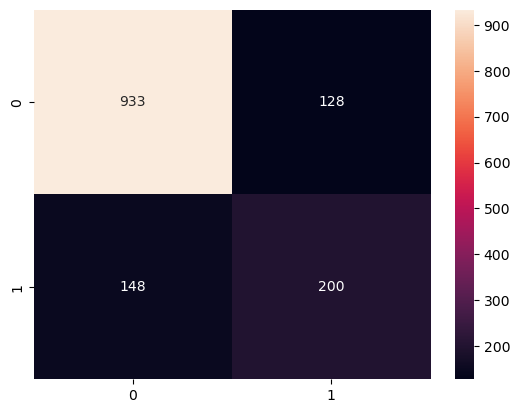

```python
from sklearn.metrics import confusion_matrix

cm = confusion_matrix(y_test, y_pred)

sns.heatmap(cm, annot= True, fmt='0.0f')
```

```python
from sklearn.metrics import accuracy_score, precision_score, recall_score, f1_score
print('Accuracy: ', accuracy_score(y_test, y_pred))
print('Precision: ', precision_score(y_test, y_pred))
print('Recall: ', recall_score(y_test, y_pred))
print('F1-Score: ', f1_score(y_test, y_pred))
```

```
Accuracy:  0.8041163946061036
Precision:  0.6097560975609756
Recall:  0.5747126436781609
F1-Score:  0.5917159763313609
```

```python
print('Precision: ', precision_score(y_test, y_pred, pos_label=0))
```

```
Precision:  0.8630897317298798
```

```python
print('Precision: ', precision_score(y_test, y_pred, average='weighted'))
```

```
Precision:  0.8005204594156294
```